# TITULO DE PRUEBA

Subtítulo de prueba

[figure not shown]

## CARGANDO DATOS

```r
# Funciones

## Función para crear flextable
ftable <- function(x) {
  x %>%
    flextable() %>%
    theme_vanilla() %>%
    color(part = "footer", color = "#666666") %>%
    color( part = "header", color = "#FFFFFF") %>%
    bg( part = "header", bg = "#2c7fb8") %>%
    fontsize(size = 11) %>%
    font(fontname = 'Calibri') %>%
    # Ajustes de ancho y tipo de alineación de las columnas
    set_table_properties(layout = "autofit") %>%
    # width(j=1, width = 3) %>%
    align(i = NULL, j = c(2:ncol(x)), align = "right", part = "all")
}
```

## 6.5 Ejemplo práctico: Predicción de precios de viviendas

Se reunió a un conjunto de especialistas inmobiliarios para generar una batería de indicadores capaces de predecir el precio de una vivienda en Colombia. Para ello los especialistas analizaron información relativa a la zona (estrato, caminabilidad, zonas verdes, seguridad), información del mercado inmobiliario(índice de vivienda nueva no cubierta, grado de saturación de la oferta), características de la propiedad(metro cuadrados construidos, nro de habitaciones, nro de baños, acabados).

Con toda esta información se les pidió conformar un índice sintético que reuniera todos los atributos relevantes de la unidad en una única cantidad numérica conocida como índice de valuación inmobiliaria. Este valor va de 0 a 100, donde el 0 está asociado a una vivienda con pésimas características y 100 para viviendas con óptimas características. Para la conformación del índice los expertos usaron todo su conocimiento de negocio para ponderar los atributos antes listados según su importancia, en un esfuerzo por capturar los aspectos que permiten predecir el valor de la vivienda.

Se le ha encomendado a usted realizar un análisis del poder predictivo de la herramienta para lo cual usted decidió pasar 1500 viviendas por la calculadora generada por los expertos, de tal manera que ésta le arrojara el valor de índice correspondiente. Acto seguido usted conformó un dataset con la información del índice y el precio de la vivienda en lista 0 (precio de compra sobre planos). Usted conocía el precio real de estas 1500 viviendas gracias a que constituyen proyectos de reciente lanzamiento, y los precios de mercado fueron facilitados por los constructores con los que usted tiene convenio para la venta de esas viviendas.

Las preguntas a resolver son:

- ¿Está el indice de valuación inmobiliaria relacionada con el precio real de la vivienda? Apóyese en herramientas gráficas.
- ¿Considera usted que un modelo de regresión lineal sería un buen modelo para capturar el poder predictor que tiene el índice? Justifique usando criterios de adecuación del modelo.
- Teniendo en cuenta que usted sólo posee una muestra de 1500 viviendas y no la base completa del mercado inmobiliario, ¿Qué puede inferir de los betas asociados al modelo?
- ¿Cuál es el error estándar estimado del beta1 del modelo y del intercepto? ¿Qué le dicen estos valores sobre la calidad del modelo?
- ¿Qué le dicen los valores p de los betas sobre la significancia estadística de los mismos en el modelo?
- Ejecute una análisis de varianza sobre los residuales del modelo. ¿Qué concluye sobre la calidad general del modelo, más allá del análisis de cada beta particular?
- ¿Cómo interpretaría el coeficiente de determinación $R²$ del modelo?
- ¿Considera que podría haber usado otro enfoque distinto para evaluar la capacidad predictiva de la herramienta?
- ¿Qué complicaciones crees que puede tener en la práctica crear una calculadora de tal estilo?

Pregunta 1: Explorando relación lineal

```r
datos_inm <- read_csv(file="precios_inm.csv")
datos_inm %>%
  head(10) %>%
  ftable()
```

| IVI | precio |
| --- | --- |
| 16.26586 | 106,550,000 |
| 34.68015 | 208,200,000 |
| 32.22654 | 202,100,000 |
| 25.89679 | 119,550,000 |
| 26.32597 | 153,000,000 |
| 43.07961 | 264,450,000 |
| 18.47640 | 112,850,000 |
| 31.22565 | 181,050,000 |
| 28.39013 | 203,300,000 |
| 28.01285 | 144,350,000 |

```r
datos_inm$precio <-datos_inm$precio/1e6
datos_inm %>%
  head(10) %>%
  ftable()
```

| IVI | precio |
| --- | --- |
| 16.26586 | 106.55 |
| 34.68015 | 208.20 |
| 32.22654 | 202.10 |
| 25.89679 | 119.55 |
| 26.32597 | 153.00 |
| 43.07961 | 264.45 |
| 18.47640 | 112.85 |
| 31.22565 | 181.05 |
| 28.39013 | 203.30 |
| 28.01285 | 144.35 |

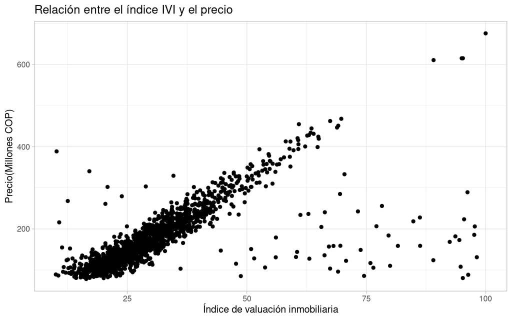

```r
# Un pequeño test de correlación
correlation_test <- cor.test(x = datos_inm$IVI, y =datos_inm$precio)
datos_inm %>%
  ggplot(aes(x= IVI, y= precio)) +
  geom_point()+ theme_light()+
  labs(title="Relación entre el índice IVI y el precio",
       x="Índice de valuación inmobiliaria",
       y="Precio(Millones COP)")
```

```r
print(correlation_test)
```

```
##
##  Pearson's product-moment correlation
##
## data:  datos_inm$IVI and datos_inm$precio
## t = 37.229, df = 1498, p-value < 0.00000000000000022
## alternative hypothesis: true correlation is not equal to 0
## 95 percent confidence interval:
##  0.6659900 0.7186345
## sample estimates:
##       cor
## 0.6932358
```

Podemos observar que si hay una relación lineal entre las variables, excepto por la zona de valores altos de IVI que presenta un comportamiento ambugüo pues existe zonas donde la relación parece estar presente y zonas donde no. Además la prueba de significaciancia para el índice de correlación arroja un p valor menor a 0.05, lo que como mínimo estaría indicando la presencia de correlación diferente de cero entre las variables. Se estima una correlación cercana a 0.69

Pregunta 2: Adecuación del modelo

Calcularemos el modelo de regresión lineal bajo la estructura:

$Precio = \beta_0 + \beta_1IVI + e \text{~}N(0, {\sigma^2}_e)$, para ello usamos la función lm de R

```r
modelo_precios <- lm(formula = precio~IVI, data=datos_inm)
print(summary(modelo_precios))
```

```
##
## Call:
## lm(formula = precio ~ IVI, data = datos_inm)
##
## Residuals:
##     Min      1Q  Median      3Q     Max
## -341.54  -22.04   -3.94   22.09  291.50
##
## Coefficients:
##             Estimate Std. Error t value            Pr(>|t|)
## (Intercept)  58.5302     3.4565   16.93 <0.0000000000000002 ***
## IVI           3.8164     0.1025   37.23 <0.0000000000000002 ***
## ---
## Signif. codes:  0 '***' 0.001 '**' 0.01 '*' 0.05 '.' 0.1 ' ' 1
##
## Residual standard error: 52.33 on 1498 degrees of freedom
## Multiple R-squared:  0.4806, Adjusted R-squared:  0.4802
## F-statistic:  1386 on 1 and 1498 DF,  p-value: < 0.00000000000000022
```

Recuerde que debe abstenerse de leer cualquier dato de esta tabla hasta que haya hecho verificación de supuestos: Normalidad, homocedasticidad del error, independencia del error. Inspeccionemos normalidad:

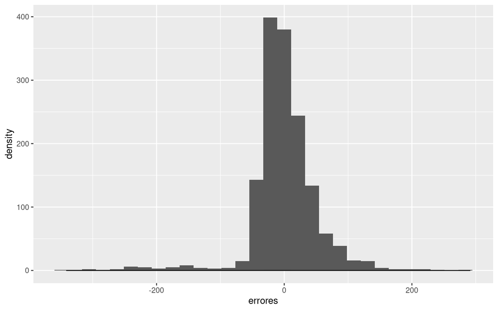

```r
errores <- modelo_precios$residuals
datos_inm$errores <- errores

datos_inm %>%
  ggplot(aes(x=errores))+
  geom_histogram()+
  geom_density()
```

```r
test_normalidad <- lillie.test(errores)
print(test_normalidad)
```

```
##
##  Lilliefors (Kolmogorov-Smirnov) normality test
##
## data:  errores
## D = 0.1401, p-value < 0.00000000000000022
```

Una alternativa práctica acá es dar por sentado que la calculadora no es útil para predecir precios muy altos y que en particular falla cuando IVI>60. Removeremos estos datos y correremos de nuevo el modelo.

```r
datos_mod <- datos_inm[datos_inm$IVI<=60, ]
modelo_precios_2 <- lm(formula = precio~IVI, data=datos_mod)
print(summary(modelo_precios_2))
```

```
##
## Call:
## lm(formula = precio ~ IVI, data = datos_mod)
##
## Residuals:
##     Min      1Q  Median      3Q     Max
## -217.02  -15.60   -1.07   14.87  331.28
##
## Coefficients:
##             Estimate Std. Error t value            Pr(>|t|)
## (Intercept) -4.30142    2.66739  -1.613               0.107
## IVI          6.08566    0.08751  69.540 <0.0000000000000002 ***
## ---
## Signif. codes:  0 '***' 0.001 '**' 0.01 '*' 0.05 '.' 0.1 ' ' 1
##
## Residual standard error: 30.25 on 1435 degrees of freedom
## Multiple R-squared:  0.7712, Adjusted R-squared:  0.771
## F-statistic:  4836 on 1 and 1435 DF,  p-value: < 0.00000000000000022
```

De nuevo evite leer esta tabla hasta no comprobar supuestos:

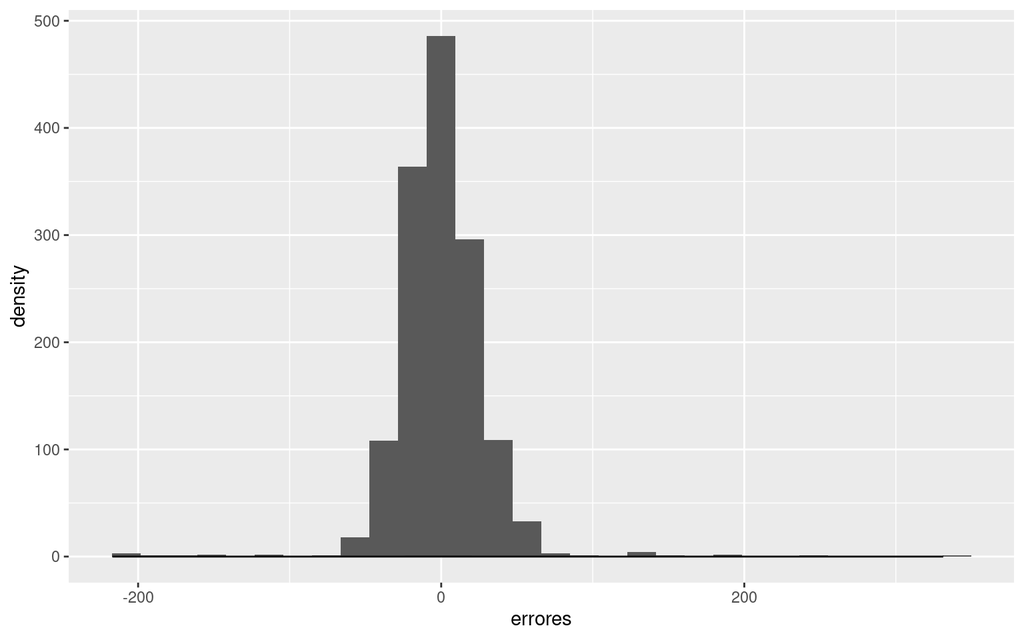

```r
errores_mod <- modelo_precios_2$residuals
datos_mod$errores <- errores_mod

datos_mod %>%
  ggplot(aes(x=errores))+
  geom_histogram()+
  geom_density()
```

```r
test_normalidad_2 <- lillie.test(errores_mod)
print(test_normalidad_2)
```

```
##
##  Lilliefors (Kolmogorov-Smirnov) normality test
##
## data:  errores_mod
## D = 0.079921, p-value < 0.00000000000000022
```

```
## [1] "Este es el valor del estadístico: 0.0799209410164159 y esta es la posición en la que ocurre la máxima diferencia 1243"
## x_posicion: 23.876 y_inferior: 0.78508 y_superior: 0.865
```

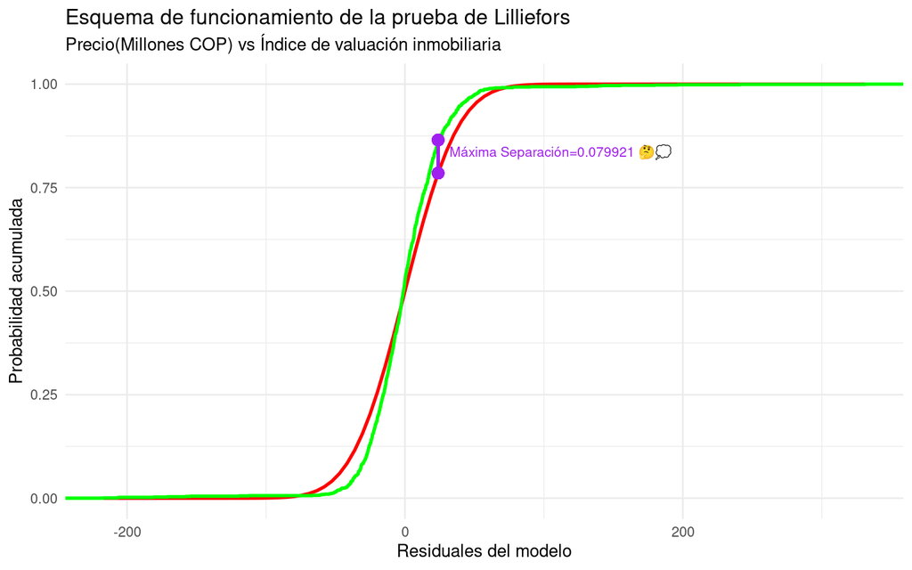

```r
#Usamos nuestra función generalizada la cual gráfica la prueba Lilliefors en un función de la comparación de las distribuciones acumuladas

colnames(datos_mod)<-c("x","y","errores")
graph_lilliefors(df=datos_mod, for_residuals=TRUE,
                 x_label="Índice de valuación inmobiliaria",
                 y_label="Precio(Millones COP)")
```

```r
print(lillie.test(datos_mod$errores))
```

```
##
##  Lilliefors (Kolmogorov-Smirnov) normality test
##
## data:  datos_mod$errores
## D = 0.079921, p-value < 0.00000000000000022
```